# BLAST Day 2

Prof. Harbert

October 2, 2018

### More: BLAST all query sequences from transcript file

First, test this command out with a somewhat larger subset of the transcript data:

```bash
head -10000 data/transcripts.fna > data/subtranscripts.fna

ncbi-blast-2.7.1+/bin/blastn.exe -db data/genome.fna -query data/subtranscripts.fna -outfmt 6 -max_target_seqs 1 -evalue 1e-100 -ungapped -num_threads 2 -out blastout.tab
```

How long did that take?

We can look at the blastout.tab file using cat or head:

```bash
head blastout.tab
```

## Plotting BLAST output in R

Start up RStudio and read the data in (your paths may be slightly different so check those if you are getting errors).

```r
setwd('C:/Users/rharbert/blast2')
res = read.table('blastout.tab')
head(res)
```

```
##            V1           V2      V3  V4 V5 V6   V7   V8      V9     V10
## 1 NM_000014.5 NC_000012.12 100.000 467  0  0    1  467 9116229 9115763
## 2 NM_000014.5 NC_000012.12 100.000 231  0  0 2621 2851 9091429 9091199
## 3 NM_000014.5 NC_000012.12 100.000 229  0  0 1646 1874 9101675 9101447
## 4 NM_000014.5 NC_000012.12 100.000 228  0  0 3910 4137 9074786 9074559
## 5 NM_000014.5 NC_000012.12 100.000 222  0  0 4134 4355 9072874 9072653
## 6 NM_000014.5 NC_000012.12  98.701 231  3  0 2621 2851 9165367 9165137
##         V11 V12
## 1  0.00e+00 898
## 2 1.99e-121 444
## 3 2.86e-120 440
## 4 1.08e-119 439
## 5 3.21e-116 427
## 6 3.21e-116 427
```

```r
colnames(res) = c('qseqid', 'sseqid', 'pident', 'length', 'mismatch', 'gapopen', 'qstart', 'qend', 'sstart', 'send', 'evalue', 'bitscore')
sam = res[sample(x=seq(1, nrow(res)), size = 1000),]
```

Then load ggplot and try some data visualization of your BLAST results.

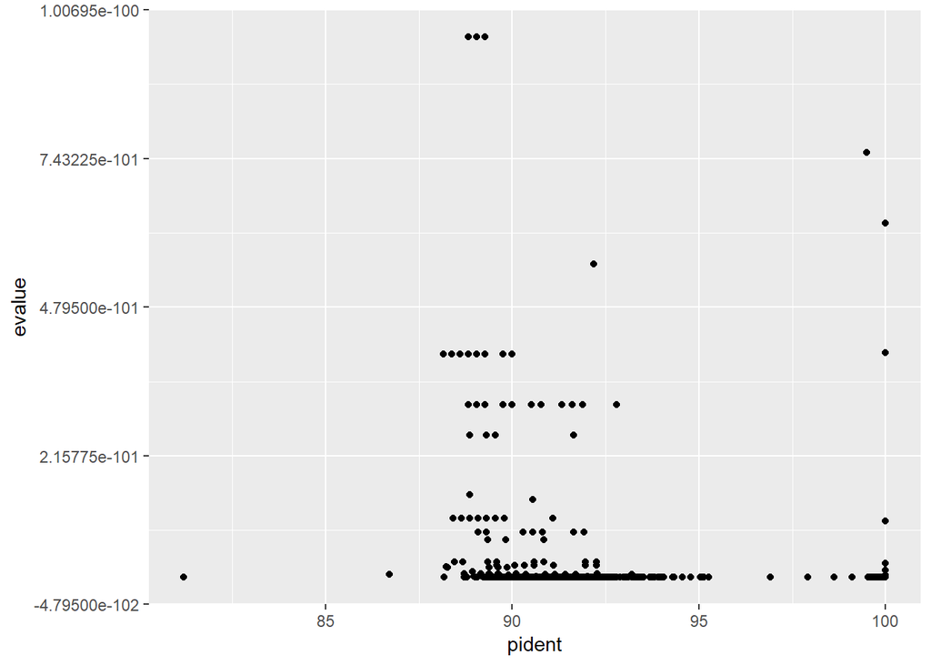

```r
library(ggplot2)
ggplot(data=sam, aes(x=pident, y=evalue)) + geom_point()
```

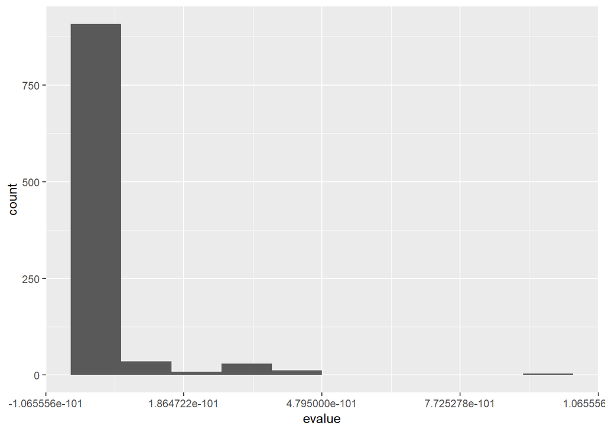

```r
ggplot(data=sam, aes(x=evalue)) + geom_histogram(bins=10)
```

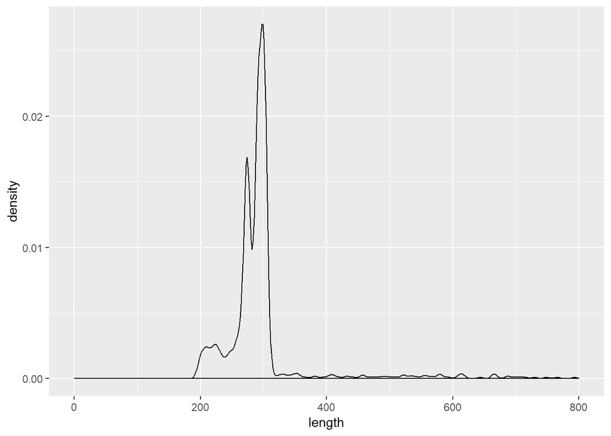

```r
ggplot(data=sam, aes(x=length)) + geom_density() + xlim(c(0,800))
```

### genoPlotR – An R package for visualizing genomic data

First we need to pull just a few of our blast hits.

```bash
#These correspond roughly to the hits to "N"
ncbi-blast-2.7.1+/bin/blastdbcmd.exe -db data/genome.fna -range 9070000-9090000 -entry all > data/blasthits.fa
```

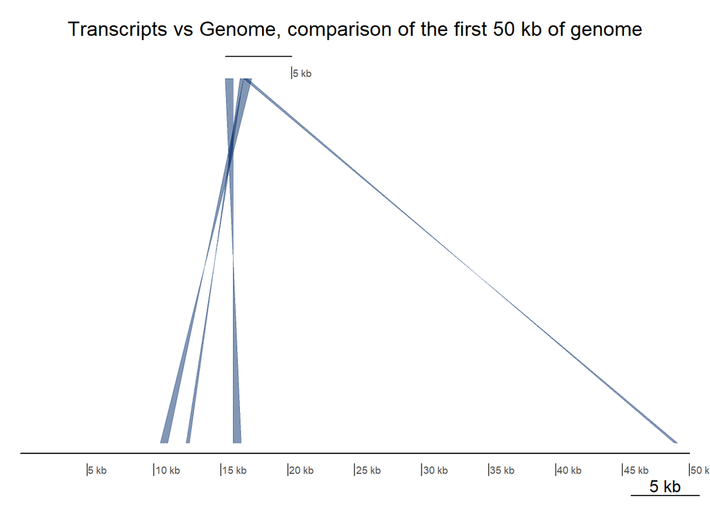

```r
#install.package('genoPlotR')

library(genoPlotR)
setwd('C:/Users/rharbert/blast2')

tr <- read_dna_seg_from_fasta('data/transcripts.fna')
ge <- read_dna_seg_from_fasta('data/blasthits.fa')
trvsge <- read_comparison_from_blast('blastout.tab')
xlims <- list(c(1,5000), c(1,50000))
plot_gene_map(dna_segs=list(tr, ge),
  comparisons=list(trvsge),
  xlims=xlims,
  main="Transcripts vs Genome, comparison of the first 50 kb of genome",
  gene_type="side_blocks",
  dna_seg_scale=TRUE,
  scale=TRUE)
```

Ok. That’s a lot and without knowing much about where we are in the genome there is not much to get from that plot. Let’s try zooming in to just just a few kb.

[figure not shown]

```r
xlims <- list(c(1,1000), c(1,5000))
plot_gene_map(dna_segs=list(tr, ge),
  comparisons=list(trvsge),
  xlims=xlims,
  main="Transcripts vs Genome, comparison of the first 50 kb of genome",
  gene_type="side_blocks",
  dna_seg_scale=TRUE,
  scale=TRUE)
```

[figure not shown]

```r
xlims <- list(c(1000,2000), c(1,5000))
plot_gene_map(dna_segs=list(tr, ge),
  comparisons=list(trvsge),
  xlims=xlims,
  main="Transcripts vs Genome, comparison of the first 50 kb of genome",
  gene_type="side_blocks",
  dna_seg_scale=TRUE,
  scale=TRUE)
```

## Homework:

Get data for mitochondria from platypus and chimps. Build a blast database from one and query the other. Then build a map of the blast hits.

The mitochondrial sequences are located on the course GitHub repository

```bash
curl https://raw.githubusercontent.com/rsh249/bioinformatics/master/data/pan.fasta > data/pan.fa

curl https://raw.githubusercontent.com/rsh249/bioinformatics/master/data/platypus.fasta > data/platypus.fa
```

Then …

```bash
ncbi-blast-2.7.1+/bin/makeblastdb.exe -in data/pan.fa -dbtype nucl -title pan


ncbi-blast-2.7.1+/bin/blastn.exe -db data/pan.fa -query data/platypus.fa -outfmt 6 -max_target_seqs 100 -evalue 1 -out comp.out
```

And plot as before:

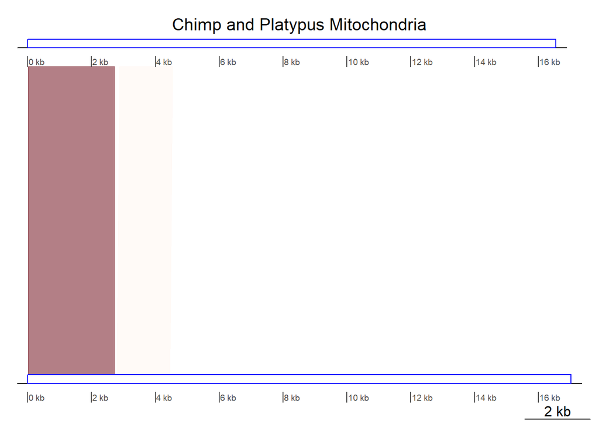

```r
library(genoPlotR)
setwd('C:/Users/rharbert/blast2')

tr <- read_dna_seg_from_fasta('data/pan.fa')
ge <- read_dna_seg_from_fasta('data/platypus.fa')
trvsge <- read_comparison_from_blast('comp.out')

plot_gene_map(dna_segs=list(tr, ge),
  comparisons=list(trvsge),
  main="Chimp and Platypus Mitochondria",
  gene_type="side_blocks",
  dna_seg_scale=TRUE,
  scale=TRUE)
```

Once you have this working manipulate one of the parameters to blastn including: ‘word_size’, ‘evalue’, ‘gapopen’, or ‘gapextend’.

Then post at least two versions of the graph to [#blast](https://bio200-bioinformatics.slack.com/messages/CD5UY3933) with a comment on your interpretation of the data you are showing.